# Plotting with ggplot2 - lecture code exaples

Giulio Genova - giulio.genova@eurac.edu

2020

This tutorial gives you an overview on how to plot using the R package ggplot2. For this tutorial it is required to install the following packages:

```r
library(ggplot2)
library(dplyr)
```

# Read Data

Let’s start with reading our soil dataset

```r
df = read.csv("data/soil_data.csv")
df = rename(df, texture = textabbr_fingprob, ph = ph_cacl2, som = som_elmntprc,
            p = p_calmg100g , k = k_calmg100g, mg = mg_catmgkg, b =  b_catmgkg ,
            mn = mn_catmgkg,cu =  cu_catmgkg,zn =  zn_catmgkg)
```

# Box plot

Let’s try a boxplot for cu you can do “mapping” of the aesthetics direcly in the **ggplot()** funciton you wou want your **geom_** functions to intherit them

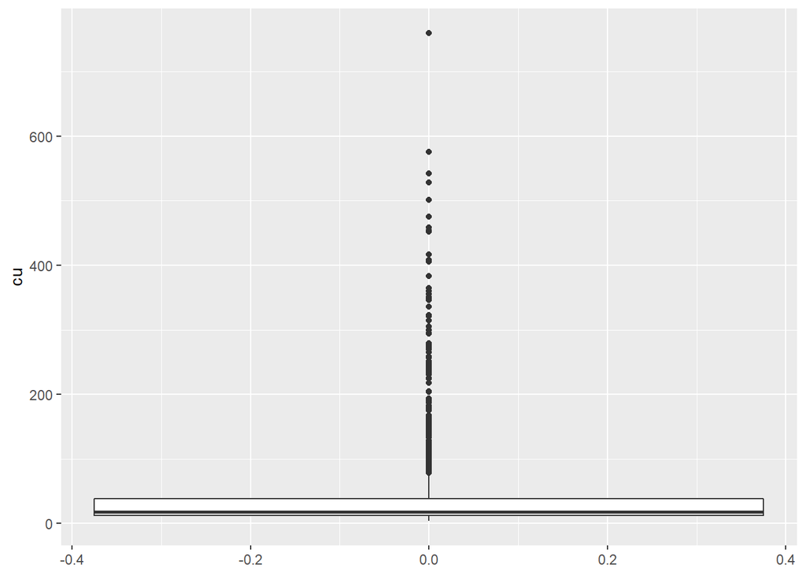

```r
ggplot(df,aes(y = cu))+
  geom_boxplot()
```

The previous works but it is not really informative. Let’s try make it better. We map the “x” axis to to landuse to make as many boxplots as the categories of landuse

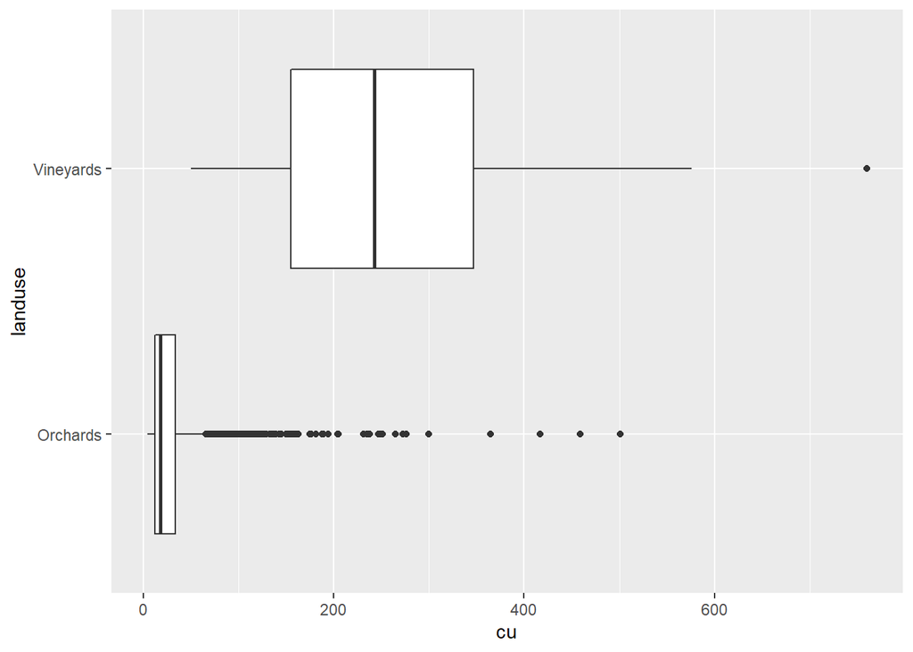

```r
ggplot(df,aes(y = cu,x = landuse))+
  geom_boxplot()+
  coord_flip()
```

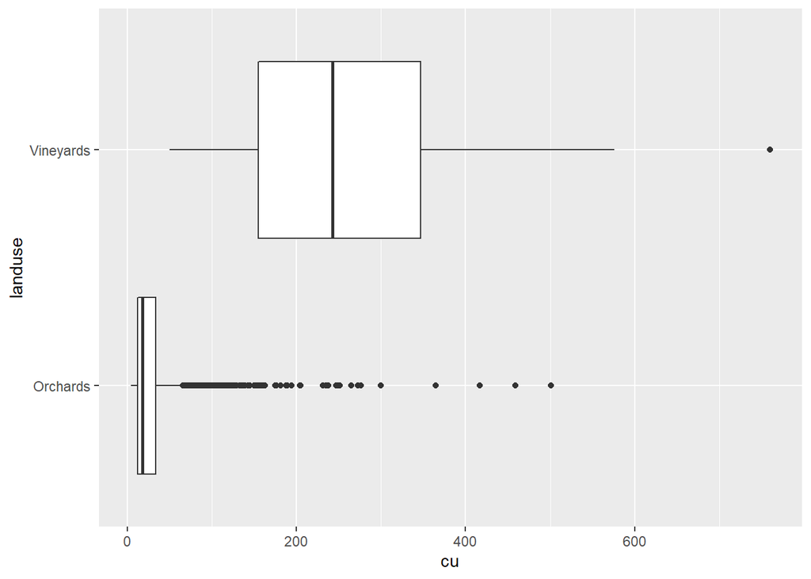

```r
ggplot(df,aes(y = landuse,x = cu))+
  geom_boxplot()
```

Add color

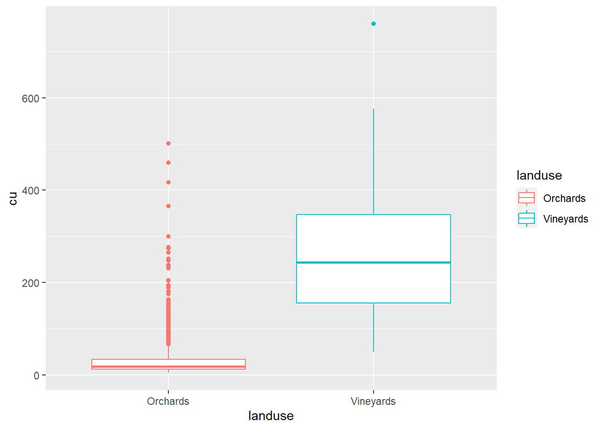

```r
ggplot(df,aes(y = cu,x = landuse,color = landuse))+
  geom_boxplot()
```

Add fill

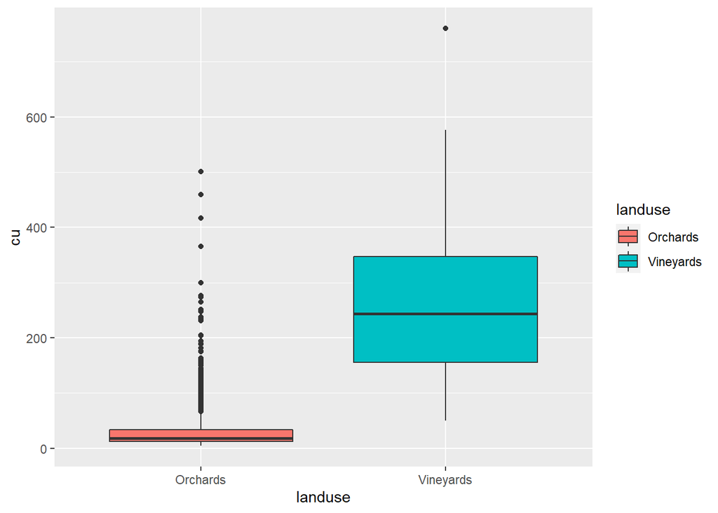

```r
ggplot(df,aes(y = cu,x = landuse,fill = landuse))+
  geom_boxplot()
```

# Bar plot

Let’s try a bar plot for landuse

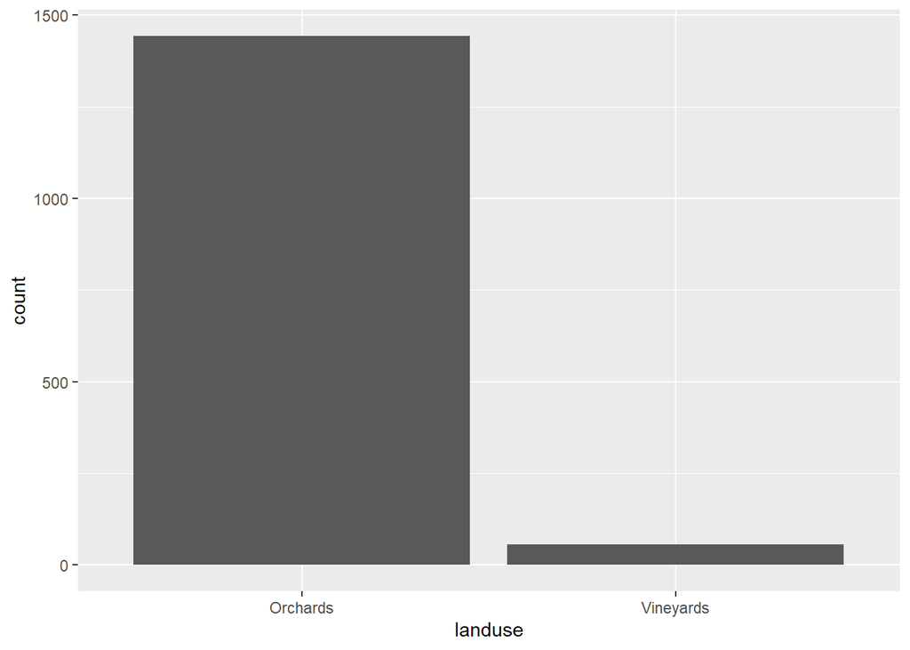

```r
ggplot(df,aes(landuse))+
  geom_bar()
```

And of texture

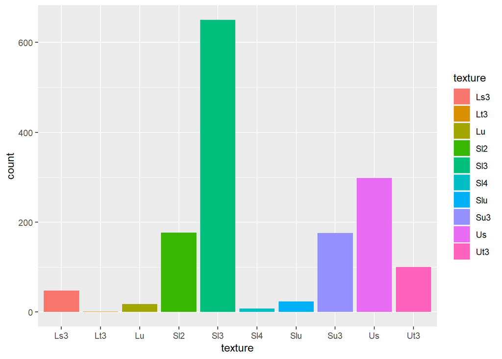

```r
ggplot(df,aes(texture,fill = texture))+
  geom_bar()
```

# Stacked bar plot

Stacked bar plot. The basic version works but is not very informative as orchards are much more than vineyards

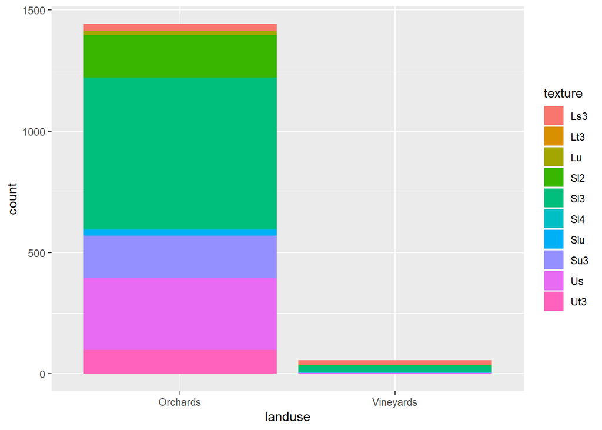

```r
ggplot(df, aes(fill=texture, x=landuse)) +
  geom_bar()
```

We now change the way the bars a stacked using *position = “fill”* in **geom_bar()**

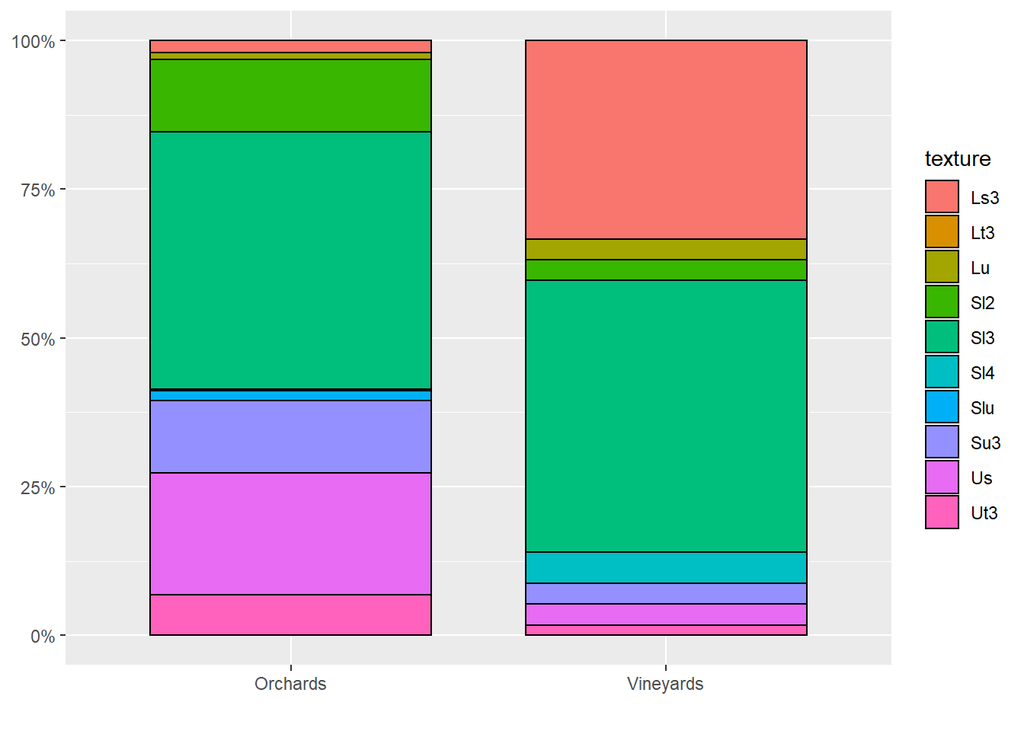

```r
ggplot(df,aes(x=landuse,fill=texture))+
  labs(y=NULL,x="")+
  geom_bar(position = "fill",colour="black",width = 0.75)+
  scale_y_continuous(labels = scales::percent)
```

Could make sense to invert the aesthetics. We plot texture on the x axis and landuse to fill

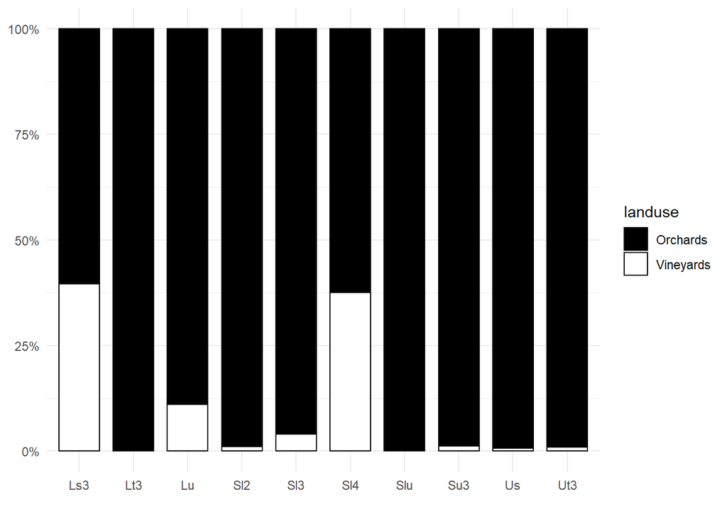

```r
ggplot(df,aes(x=texture,fill=landuse))+
  labs(y=NULL,x="")+
  geom_bar(position = "fill",colour="black",width = 0.75)+
  scale_fill_manual (values =c("black","white"))+
  scale_y_continuous(labels = scales::percent)+
  theme_minimal()
```